# Quantitative Genomics and Genetics 2016

## Computer Lab 4

– 25 February 2016

– Author: Jin Hyun Ju (jj328@cornell.edu)

### 1. Boolean Data Type

- Boolean data type is a data type with only two possible values, TRUE and FALSE.
- Its main usage is for testing conditions.
- In R and many other languages, the actual values for TRUE and FALSE are 1 and 0.
- This can be illustrated as follows

```r
sum(TRUE + TRUE)
```

```
[1] 2
```

```r
sum(FALSE)
```

```
[1] 0
```

- Booleans are useful in testing conditions.
- For example, if you are interested in finding out if certain elements of a vector are greater than or smaller than a certain value, you can use >, <, >=, <=

```r
example.vector <- seq(1,25,by= 2)
example.vector
```

```
 [1]  1  3  5  7  9 11 13 15 17 19 21 23 25
```

```r
example.vector > 10
```

```
 [1] FALSE FALSE FALSE FALSE FALSE  TRUE  TRUE  TRUE  TRUE  TRUE  TRUE
[12]  TRUE  TRUE
```

```r
example.vector >= 15
```

```
 [1] FALSE FALSE FALSE FALSE FALSE FALSE FALSE  TRUE  TRUE  TRUE  TRUE
[12]  TRUE  TRUE
```

```r
example.vector <= 5
```

```
 [1]  TRUE  TRUE  TRUE FALSE FALSE FALSE FALSE FALSE FALSE FALSE FALSE
[12] FALSE FALSE
```

- Each position where the value meets the condition will be marked with TRUE, and with FALSE otherwise.
- Since TRUE and FALSE are essentially 1 and 0, you can easily find out how many elements satisfy the condition by simply taking the sum of the result.

```r
sum(example.vector >10)
```

```
[1] 8
```

- The same applies to matrices

```r
example.mx <- matrix(c(2,5,7,-2,-5,-10), ncol = 3, byrow=T)
example.mx < 1
```

```
      [,1]  [,2]  [,3]
[1,] FALSE FALSE FALSE
[2,]  TRUE  TRUE  TRUE
```

- You can also check if an element is equal to a specific value

```r
dim(example.mx)[1] == 2
```

```
[1] TRUE
```

```r
example.vector == 3
```

```
 [1] FALSE  TRUE FALSE FALSE FALSE FALSE FALSE FALSE FALSE FALSE FALSE
[12] FALSE FALSE
```

### 2. Boolean Algebra

- Boolean algebra allows you to combine multiple conditions.
- There are three basic operations AND (&), OR (|) and NOT (!).
- The AND (&) operator returns TRUE **only if all conditions are TRUE**

```r
FALSE & FALSE
```

```
[1] FALSE
```

```r
TRUE & FALSE
```

```
[1] FALSE
```

```r
TRUE & TRUE
```

```
[1] TRUE
```

```r
# Example of an AND operator
example.vector > 5 & example.vector < 10
```

```
 [1] FALSE FALSE FALSE  TRUE  TRUE FALSE FALSE FALSE FALSE FALSE FALSE
[12] FALSE FALSE
```

```r
# if you want to see the actual elements
example.vector[example.vector >10 & example.vector < 20]
```

```
[1] 11 13 15 17 19
```

- The OR (|) operator returns TRUE **when at least one condition is TRUE**

```r
FALSE | FALSE
```

```
[1] FALSE
```

```r
TRUE | FALSE
```

```
[1] TRUE
```

```r
TRUE | TRUE
```

```
[1] TRUE
```

```r
# Example of an OR operator
example.vector > 10 | example.vector < 20
```

```
 [1] TRUE TRUE TRUE TRUE TRUE TRUE TRUE TRUE TRUE TRUE TRUE TRUE TRUE
```

```r
example.vector < 10 | example.vector > 20
```

```
 [1]  TRUE  TRUE  TRUE  TRUE  TRUE FALSE FALSE FALSE FALSE FALSE  TRUE
[12]  TRUE  TRUE
```

- NOT (!) returns the opposite result

```r
!(TRUE)
```

```
[1] FALSE
```

```r
example.vector != 3
```

```
 [1]  TRUE FALSE  TRUE  TRUE  TRUE  TRUE  TRUE  TRUE  TRUE  TRUE  TRUE
[12]  TRUE  TRUE
```

### 3. More on Vector Elements

- If you want to check whether a certain element is present or absent in a vector use the %in% operator

```r
fruits <- c("banana","apple","strawberry","peach","mango")

"mango" %in% fruits
```

```
[1] TRUE
```

```r
"durian" %in% fruits
```

```
[1] FALSE
```

- We can see what the ! operator is doing by wrapping the previous expression with !()

```r
!("durian" %in% fruits)
```

```
[1] TRUE
```

- You can find out the index of a certain entry in a vector by using the which() function

```r
which(fruits == "apple")
```

```
[1] 2
```

- If you want to compare two vectors,

```r
fruits2 <- c("orange","banana","durian","cherry","mango","apple")

fruits2 %in% fruits
```

```
[1] FALSE  TRUE FALSE FALSE  TRUE  TRUE
```

```r
# show me the position
which(fruits2 %in% fruits)
```

```
[1] 2 5 6
```

```r
#show me the elements
fruits2[fruits2 %in% fruits]
```

```
[1] "banana" "mango"  "apple"
```

```r
# There is also a function for this
intersect(fruits2, fruits)
```

```
[1] "banana" "mango"  "apple"
```

### 2. If / else statements

- By using if and else statements you can insert condition specific executions in your script
- The code inside an if statement will only be executed when the condition is TRUE
- The structure looks like this

```r
if (condition) {
  do stuff
} else {
  do stuff
}

# OR you can add more levels by using else if

if(condition){
  do stuff
} else if (condition 2){
  do stuf
} else {
  do stuff
}
```

- Here is a simple example

```r
# Loop over individual elements in example.vector
for( i in example.vector){

    if( i < 10 ){
        cat(i, "is smaller than 10 \n")
    } else if ( 10 <= i & i < 20){
        cat(i, "is in the interval [10,20) \n")
    } else {
        cat(i, "is larger than 20 \n")
    }

}
```

```
1 is smaller than 10
3 is smaller than 10
5 is smaller than 10
7 is smaller than 10
9 is smaller than 10
11 is in the interval [10,20)
13 is in the interval [10,20)
15 is in the interval [10,20)
17 is in the interval [10,20)
19 is in the interval [10,20)
21 is larger than 20
23 is larger than 20
25 is larger than 20
```

### Exercise

- Using if/else statements and plotting functions create a function that can generate a histogram, a scatter plot, or a density plot depending on the input.

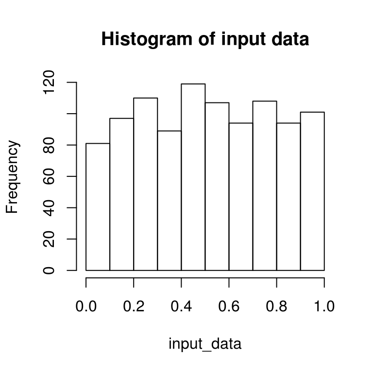

```r
sample_data <- runif(1000)

data_plotter(sample_data, plot_type = "histogram")
```

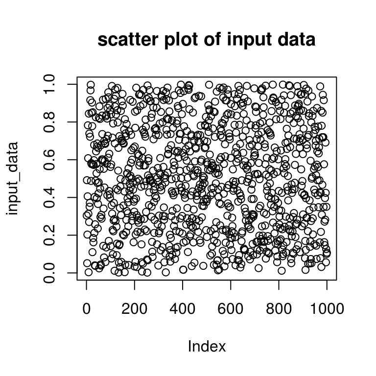

```r
data_plotter(sample_data, plot_type = "scatter")
```

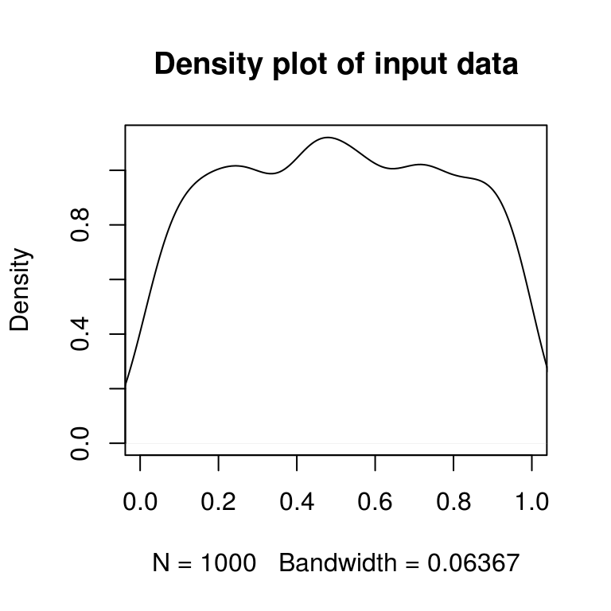

```r
data_plotter(sample_data, plot_type = "density")
```